# Solution_FullCode_Additional__Project_AML

## Problem Statement

### Business context

Employee Promotion means the ascension of an employee to higher ranks, this aspect of the job is what drives employees the most. The ultimate reward for dedication and loyalty towards an organization and the HR team plays an important role in handling all these promotion tasks based on ratings and other attributes available.

The HR team in JMD company stored data on the promotion cycle last year, which consists of details of all the employees in the company working last year and also if they got promoted or not, but every time this process gets delayed due to so many details available for each employee - it gets difficult to compare and decide.

### Objective

For the upcoming appraisal cycle, the HR team wants to utilize the stored data and leverage machine learning to make a model that will predict if a person is eligible for promotion or not. You, as a data scientist at JMD company, need to come up with the best possible model that will help the HR team to predict if a person is eligible for promotion or not.

### Data Description

- employee_id: Unique ID for the employee
- department: Department of employee
- region: Region of employment (unordered)
- education: Education Level
- gender: Gender of Employee
- recruitment_channel: Channel of recruitment for employee
- no_ of_ trainings: no of other training completed in the previous year on soft skills, technical skills, etc.
- age: Age of Employee
- previous_ year_ rating: Employee Rating for the previous year
- length_ of_ service: Length of service in years
- awards_ won: if awards won during the previous year then 1 else 0
- avg_ training_ score: Average score in current training evaluations
- is_promoted: (Target) Recommended for promotion

## Importing necessary libraries

```python
# Installing the libraries with the specified version.
# uncomment and run the following line if Google Colab is being used
!pip3 install scikit-learn==1.2.2 seaborn==0.13.1 matplotlib==3.7.1 numpy==1.25.2 pandas==1.5.3 imbalanced-learn==0.10.1 xgboost==2.0.3 -q --user
```

```
31772.84s - pydevd: Sending message related to process being replaced timed-out after 5 seconds
```

## Loading the dataset

```python
import pandas as pd
import warnings

#Ignore warnings for now, for a cleaner looking notebook
warnings.filterwarnings("ignore")

file_path = '/Users/dg/Documents/PGP-AIML/AdvancedMachineLearning/employee_promotion.csv'
df = pd.read_csv(file_path)
```

## Data Overview

- Observations
- Sanity checks

```python
#Shape of the dataset
print("Shape of the dataset (rows, columns):", df.shape)

#Columns and Data Types
print("\nColumns in the dataset:\n", df.columns.to_list())
print("\nData Types & Non-Null Counts:")
print(df.info())

#Peek at the data
print("\nFirst 5 records:")
display(df.head())

print("\nLast 5 records:")
display(df.tail())

#Statistical Summary
print("\nStatistical Summary (Numeric Columns):")
display(df.describe())

#Missing Values
print("\nMissing Values per Column:")
print(df.isnull().sum())

#Duplicate Rows
duplicate_count = df.duplicated().sum()
print(f"\nNumber of Duplicate Rows: {duplicate_count}")
```

```
Shape of the dataset (rows, columns): (54808, 13)

Columns in the dataset:
 ['employee_id', 'department', 'region', 'education', 'gender', 'recruitment_channel', 'no_of_trainings', 'age', 'previous_year_rating', 'length_of_service', 'awards_won', 'avg_training_score', 'is_promoted']

Data Types & Non-Null Counts:
<class 'pandas.core.frame.DataFrame'>
RangeIndex: 54808 entries, 0 to 54807
Data columns (total 13 columns):
 #   Column                Non-Null Count  Dtype
---  ------                --------------  -----
 0   employee_id           54808 non-null  int64
 1   department            54808 non-null  object
 2   region                54808 non-null  object
 3   education             52399 non-null  object
 4   gender                54808 non-null  object
 5   recruitment_channel   54808 non-null  object
 6   no_of_trainings       54808 non-null  int64
 7   age                   54808 non-null  int64
 8   previous_year_rating  50684 non-null  float64
 9   length_of_service     54808 non-null  int64
 10  awards_won            54808 non-null  int64
 11  avg_training_score    52248 non-null  float64
 12  is_promoted           54808 non-null  int64
dtypes: float64(2), int64(6), object(5)
memory usage: 5.4+ MB
None

First 5 records:
```

|  | employee_id | department | region | education | gender | recruitment_channel | no_of_trainings | age | previous_year_rating | length_of_service | awards_won | avg_training_score | is_promoted |
| --- | --- | --- | --- | --- | --- | --- | --- | --- | --- | --- | --- | --- | --- |
| 0 | 65438 | Sales & Marketing | region_7 | Master's & above | f | sourcing | 1 | 35 | 5.0 | 8 | 0 | 49.0 | 0 |
| 1 | 65141 | Operations | region_22 | Bachelor's | m | other | 1 | 30 | 5.0 | 4 | 0 | 60.0 | 0 |
| 2 | 7513 | Sales & Marketing | region_19 | Bachelor's | m | sourcing | 1 | 34 | 3.0 | 7 | 0 | 50.0 | 0 |
| 3 | 2542 | Sales & Marketing | region_23 | Bachelor's | m | other | 2 | 39 | 1.0 | 10 | 0 | 50.0 | 0 |
| 4 | 48945 | Technology | region_26 | Bachelor's | m | other | 1 | 45 | 3.0 | 2 | 0 | 73.0 | 0 |

```
Last 5 records:
```

|  | employee_id | department | region | education | gender | recruitment_channel | no_of_trainings | age | previous_year_rating | length_of_service | awards_won | avg_training_score | is_promoted |
| --- | --- | --- | --- | --- | --- | --- | --- | --- | --- | --- | --- | --- | --- |
| 54803 | 3030 | Technology | region_14 | Bachelor's | m | sourcing | 1 | 48 | 3.0 | 17 | 0 | 78.0 | 0 |
| 54804 | 74592 | Operations | region_27 | Master's & above | f | other | 1 | 37 | 2.0 | 6 | 0 | 56.0 | 0 |
| 54805 | 13918 | Analytics | region_1 | Bachelor's | m | other | 1 | 27 | 5.0 | 3 | 0 | 79.0 | 0 |
| 54806 | 13614 | Sales & Marketing | region_9 | NaN | m | sourcing | 1 | 29 | 1.0 | 2 | 0 | NaN | 0 |
| 54807 | 51526 | HR | region_22 | Bachelor's | m | other | 1 | 27 | 1.0 | 5 | 0 | 49.0 | 0 |

```
Statistical Summary (Numeric Columns):
```

|  | employee_id | no_of_trainings | age | previous_year_rating | length_of_service | awards_won | avg_training_score | is_promoted |
| --- | --- | --- | --- | --- | --- | --- | --- | --- |
| count | 54808.000000 | 54808.000000 | 54808.000000 | 50684.000000 | 54808.000000 | 54808.000000 | 52248.000000 | 54808.000000 |
| mean | 39195.830627 | 1.253011 | 34.803915 | 3.329256 | 5.865512 | 0.023172 | 63.712238 | 0.085170 |
| std | 22586.581449 | 0.609264 | 7.660169 | 1.259993 | 4.265094 | 0.150450 | 13.521910 | 0.279137 |
| min | 1.000000 | 1.000000 | 20.000000 | 1.000000 | 1.000000 | 0.000000 | 39.000000 | 0.000000 |
| 25% | 19669.750000 | 1.000000 | 29.000000 | 3.000000 | 3.000000 | 0.000000 | 51.000000 | 0.000000 |
| 50% | 39225.500000 | 1.000000 | 33.000000 | 3.000000 | 5.000000 | 0.000000 | 60.000000 | 0.000000 |
| 75% | 58730.500000 | 1.000000 | 39.000000 | 4.000000 | 7.000000 | 0.000000 | 77.000000 | 0.000000 |
| max | 78298.000000 | 10.000000 | 60.000000 | 5.000000 | 37.000000 | 1.000000 | 99.000000 | 1.000000 |

```
Missing Values per Column:
employee_id                0
department                 0
region                     0
education               2409
gender                     0
recruitment_channel        0
no_of_trainings            0
age                        0
previous_year_rating    4124
length_of_service          0
awards_won                 0
avg_training_score      2560
is_promoted                0
dtype: int64

Number of Duplicate Rows: 0
```

## Exploratory Data Analysis (EDA)

- EDA is an important part of any project involving data.
- It is important to investigate and understand the data better before building a model with it.
- A few questions have been mentioned below which will help you approach the analysis in the right manner and generate insights from the data.
- A thorough analysis of the data, in addition to the questions mentioned below, should be done.

**Questions**:

1. How is the distribution of average training score of employee ?
2. How is the distribution age of employee ?
3. How does the change in length of service (`length_of_service`) vary by the employee's promotion status (`is_promoted`)?
4. How does the previous rating(`previous_year_rating`) vary by the employee's promotion status (`is_promoted`)?
5. What are the attributes that have a strong correlation with each other?

#### The below functions need to be defined to carry out the Exploratory Data Analysis.

```python
# function to plot a boxplot and a histogram along the same scale.


def histogram_boxplot(data, feature, figsize=(12, 7), kde=False, bins=None):
    """
    Boxplot and histogram combined

    data: dataframe
    feature: dataframe column
    figsize: size of figure (default (12,7))
    kde: whether to the show density curve (default False)
    bins: number of bins for histogram (default None)
    """
    f2, (ax_box2, ax_hist2) = plt.subplots(
        nrows=2,  # Number of rows of the subplot grid= 2
        sharex=True,  # x-axis will be shared among all subplots
        gridspec_kw={"height_ratios": (0.25, 0.75)},
        figsize=figsize,
    )  # creating the 2 subplots
    sns.boxplot(
        data=data, x=feature, ax=ax_box2, showmeans=True, color="violet"
    )  # boxplot will be created and a triangle will indicate the mean value of the column
    sns.histplot(
        data=data, x=feature, kde=kde, ax=ax_hist2, bins=bins, palette="winter"
    ) if bins else sns.histplot(
        data=data, x=feature, kde=kde, ax=ax_hist2
    )  # For histogram
    ax_hist2.axvline(
        data[feature].mean(), color="green", linestyle="--"
    )  # Add mean to the histogram
    ax_hist2.axvline(
        data[feature].median(), color="black", linestyle="-"
    )  # Add median to the histogram
```

```python
# function to create labeled barplots


def labeled_barplot(data, feature, perc=False, n=None):
    """
    Barplot with percentage at the top

    data: dataframe
    feature: dataframe column
    perc: whether to display percentages instead of count (default is False)
    n: displays the top n category levels (default is None, i.e., display all levels)
    """

    total = len(data[feature])  # length of the column
    count = data[feature].nunique()
    if n is None:
        plt.figure(figsize=(count + 1, 5))
    else:
        plt.figure(figsize=(n + 1, 5))

    plt.xticks(rotation=90, fontsize=15)
    ax = sns.countplot(
        data=data,
        x=feature,
        palette="Paired",
        order=data[feature].value_counts().index[:n].sort_values(),
    )

    for p in ax.patches:
        if perc == True:
            label = "{:.1f}%".format(
                100 * p.get_height() / total
            )  # percentage of each class of the category
        else:
            label = p.get_height()  # count of each level of the category

        x = p.get_x() + p.get_width() / 2  # width of the plot
        y = p.get_height()  # height of the plot

        ax.annotate(
            label,
            (x, y),
            ha="center",
            va="center",
            size=12,
            xytext=(0, 5),
            textcoords="offset points",
        )  # annotate the percentage

    plt.show()  # show the plot
```

```python
# function to plot stacked bar chart

def stacked_barplot(data, predictor, target):
    """
    Print the category counts and plot a stacked bar chart

    data: dataframe
    predictor: independent variable
    target: target variable
    """
    count = data[predictor].nunique()
    sorter = data[target].value_counts().index[-1]
    tab1 = pd.crosstab(data[predictor], data[target], margins=True).sort_values(
        by=sorter, ascending=False
    )
    print(tab1)
    print("-" * 120)
    tab = pd.crosstab(data[predictor], data[target], normalize="index").sort_values(
        by=sorter, ascending=False
    )
    tab.plot(kind="bar", stacked=True, figsize=(count + 1, 5))
    plt.legend(
        loc="lower left", frameon=False,
    )
    plt.legend(loc="upper left", bbox_to_anchor=(1, 1))
    plt.show()
```

```python
### Function to plot distributions

def distribution_plot_wrt_target(data, predictor, target):

    fig, axs = plt.subplots(2, 2, figsize=(12, 10))

    target_uniq = data[target].unique()

    axs[0, 0].set_title("Distribution of target for target=" + str(target_uniq[0]))
    sns.histplot(
        data=data[data[target] == target_uniq[0]],
        x=predictor,
        kde=True,
        ax=axs[0, 0],
        color="teal",
    )

    axs[0, 1].set_title("Distribution of target for target=" + str(target_uniq[1]))
    sns.histplot(
        data=data[data[target] == target_uniq[1]],
        x=predictor,
        kde=True,
        ax=axs[0, 1],
        color="orange",
    )

    axs[1, 0].set_title("Boxplot w.r.t target")
    sns.boxplot(data=data, x=target, y=predictor, ax=axs[1, 0], palette="gist_rainbow")

    axs[1, 1].set_title("Boxplot (without outliers) w.r.t target")
    sns.boxplot(
        data=data,
        x=target,
        y=predictor,
        ax=axs[1, 1],
        showfliers=False,
        palette="gist_rainbow",
    )

    plt.tight_layout()
    plt.show()
```

```
EDA - Q1) Distribution of avg_training_score

EDA - Q2) Distribution of age

EDA - Q3) Variation of length_of_service by promotion status (is_promoted)
```

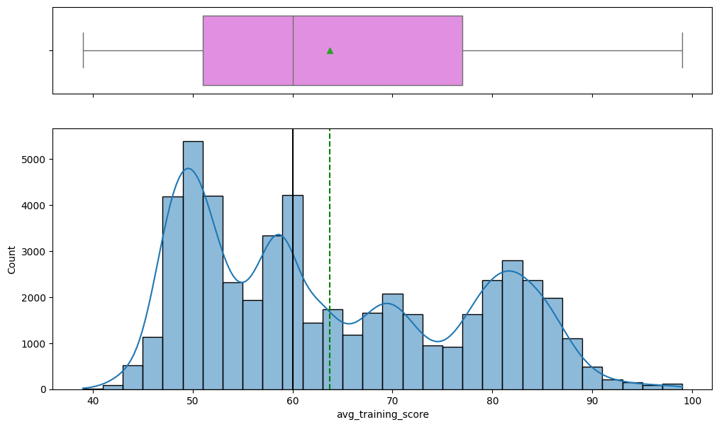

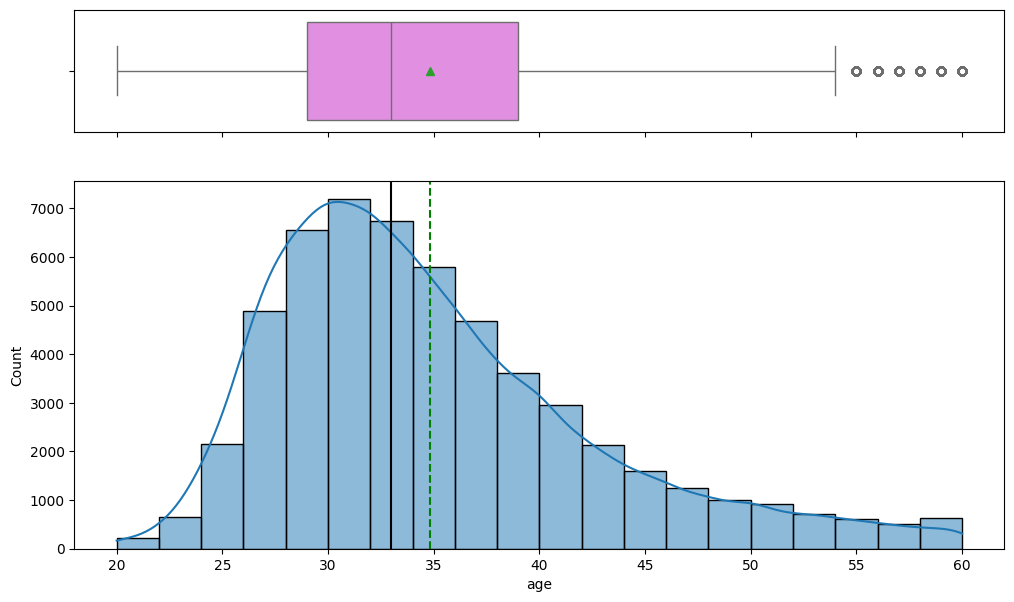

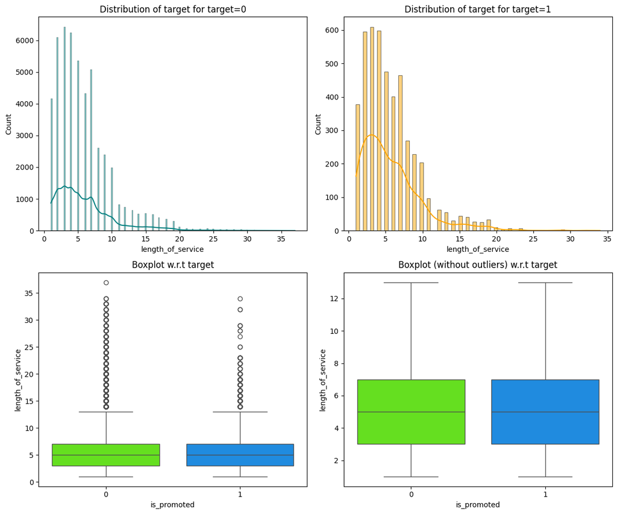

```
EDA - Q4) Variation of previous_year_rating by promotion status (is_promoted)
is_promoted               0     1    All
previous_year_rating
All                   46355  4329  50684
5.0                    9820  1921  11741
3.0                   17263  1355  18618
4.0                    9093   784   9877
2.0                    4044   181   4225
1.0                    6135    88   6223
------------------------------------------------------------------------------------------------------------------------
```

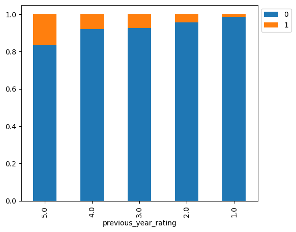

```
EDA - Q5) Correlation among features
```

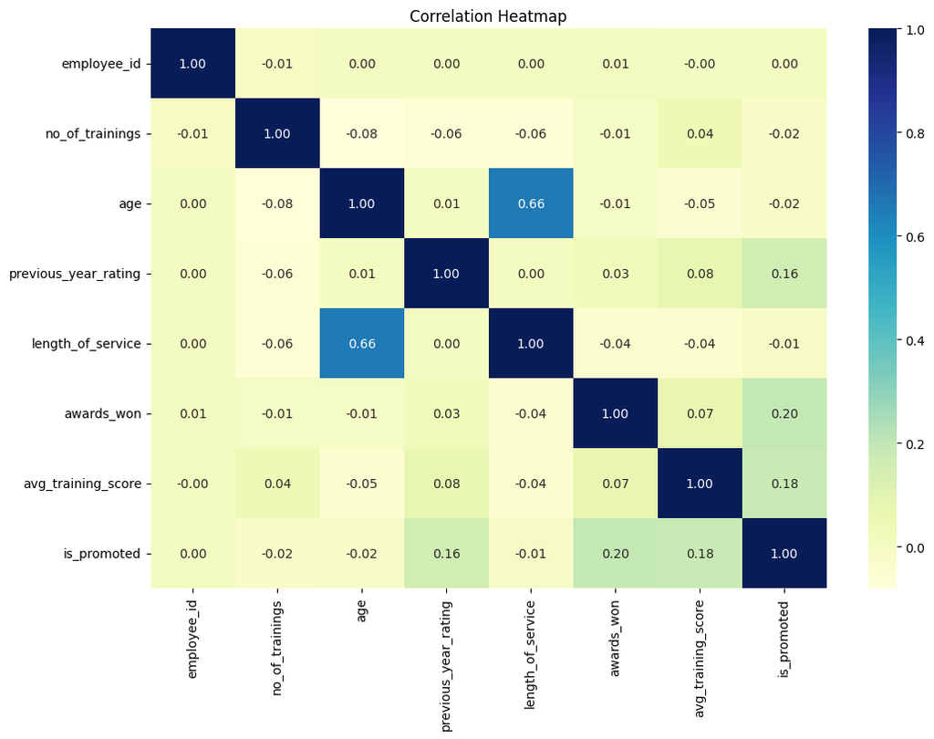

```python
import matplotlib.pyplot as plt
import seaborn as sns

# Q1) Distribution of average training score
print("EDA - Q1) Distribution of avg_training_score")
histogram_boxplot(data=df, feature='avg_training_score', kde=True, bins=30)

# Q2) Distribution of age
print("\nEDA - Q2) Distribution of age")
histogram_boxplot(data=df, feature='age', kde=True, bins=20)

# Q3) Variation of length_of_service by promotion status
print("\nEDA - Q3) Variation of length_of_service by promotion status (is_promoted)")
distribution_plot_wrt_target(data=df, predictor='length_of_service', target='is_promoted')

# Q4) Variation of previous_year_rating by promotion status
print("\nEDA - Q4) Variation of previous_year_rating by promotion status (is_promoted)")
stacked_barplot(data=df, predictor='previous_year_rating', target='is_promoted')

# Q5) Correlation among features
print("\nEDA - Q5) Correlation among features")
corr_matrix = df.corr()

plt.figure(figsize=(12, 8))
sns.heatmap(corr_matrix, annot=True, cmap='YlGnBu', fmt='.2f')
plt.title("Correlation Heatmap")
plt.show()
```

### **Q4: How does `previous_year_rating` vary by `is_promoted`?**

**Takeaway:**  
The stacked bar chart shows that **most** promoted employees had a rating in the **higher range** (for instance, 4 or 5). Employees with lower ratings (like 1 or 2) are less likely to appear in the promoted group. This points toward `previous_year_rating` being a **strong predictor** of promotion status.

### **Q5: What attributes correlate strongly with one another?**

**Takeaway:**  
The heatmap doesn’t reveal any extreme correlations above **0.7** or below **-0.7**. However, we do see a **moderate positive** correlation between `age` and `length_of_service` (which makes sense—older employees generally have more years under their belt). `previous_year_rating` also shows some positive association with `is_promoted`, reinforcing the idea that performance ratings significantly influence promotion decisions.

## Data Pre-processing

```python
print("Initial shape of the DataFrame:", df.shape)

# 1) Remove duplicate rows
df.drop_duplicates(inplace=True)
print("Duplicates removed. New shape:", df.shape)

# 2) Handle missing values (examples)
#    - Fill missing 'education' with mode
#    - Fill missing 'previous_year_rating' with median
if 'education' in df.columns:
    df['education'].fillna(df['education'].mode()[0], inplace=True)

if 'previous_year_rating' in df.columns:
    df['previous_year_rating'].fillna(df['previous_year_rating'].median(), inplace=True)

# 3) Encode categorical variables (examples)
#    Replace with actual categorical columns
from sklearn.preprocessing import LabelEncoder

cat_cols = ['department', 'gender', 'region', 'recruitment_channel', 'education']
for col in cat_cols:
    if col in df.columns:
        le = LabelEncoder()
        df[col] = le.fit_transform(df[col])

# 4) Scale numeric features (examples)
#    Replace with actual numeric columns
from sklearn.preprocessing import StandardScaler

num_cols = ['age', 'avg_training_score', 'length_of_service']
scaler = StandardScaler()

# Fit & transform columns one by one or all together
for col in num_cols:
    if col in df.columns:
        df[col] = scaler.fit_transform(df[[col]])

print("\nData Preprocessing completed.")
print("Final shape of the DataFrame:", df.shape)
display(df.head())
```

```
Initial shape of the DataFrame: (54808, 13)
Duplicates removed. New shape: (54808, 13)

Data Preprocessing completed.
Final shape of the DataFrame: (54808, 13)
```

|  | employee_id | department | region | education | gender | recruitment_channel | no_of_trainings | age | previous_year_rating | length_of_service | awards_won | avg_training_score | is_promoted |
| --- | --- | --- | --- | --- | --- | --- | --- | --- | --- | --- | --- | --- | --- |
| 0 | 65438 | 7 | 31 | 2 | 0 | 2 | 1 | 0.025598 | 5.0 | 0.500460 | 0 | -1.088040 | 0 |
| 1 | 65141 | 4 | 14 | 0 | 1 | 0 | 1 | -0.627135 | 5.0 | -0.437395 | 0 | -0.274538 | 0 |
| 2 | 7513 | 7 | 10 | 0 | 1 | 2 | 1 | -0.104948 | 3.0 | 0.265996 | 0 | -1.014085 | 0 |
| 3 | 2542 | 7 | 15 | 0 | 1 | 0 | 2 | 0.547785 | 1.0 | 0.969387 | 0 | -1.014085 | 0 |
| 4 | 48945 | 8 | 18 | 0 | 1 | 0 | 1 | 1.331064 | 3.0 | -0.906322 | 0 | 0.686874 | 0 |

## Model Building

### Model evaluation criterion

**Which metric to optimize?**

```python
# defining a function to compute different metrics to check performance of a classification model built using sklearn
def model_performance_classification_sklearn(model, predictors, target):
    """
    Function to compute different metrics to check classification model performance

    model: classifier
    predictors: independent variables
    target: dependent variable
    """

    # predicting using the independent variables
    pred = model.predict(predictors)

    acc = accuracy_score(target, pred)  # to compute Accuracy
    recall = recall_score(target, pred)  # to compute Recall
    precision = precision_score(target, pred)  # to compute Precision
    f1 = f1_score(target, pred)  # to compute F1-score

    # creating a dataframe of metrics
    df_perf = pd.DataFrame(
        {
            "Accuracy": acc,
            "Recall": recall,
            "Precision": precision,
            "F1": f1

        },
        index=[0],
    )

    return df_perf
```

### Model Building with original data

Sample code for model building with original data

Kept running into errors/situations where missing data/NaN led to error in running the model building section. So inputing a section here to analyze and impute missing values before proceeding with model building.

```python
# Inspect which columns still have missing values
print("Missing values in df before splitting:\n", df.isnull().sum())
```

```
Missing values in df before splitting:
 employee_id                0
department                 0
region                     0
education                  0
gender                     0
recruitment_channel        0
no_of_trainings            0
age                        0
previous_year_rating       0
length_of_service          0
awards_won                 0
avg_training_score      2560
is_promoted                0
dtype: int64
```

```python
import numpy as np
from sklearn.impute import SimpleImputer

# Identify numeric and categorical columns
numeric_cols = df.select_dtypes(include=[np.number]).columns
cat_cols = df.select_dtypes(exclude=[np.number]).columns

# Impute numeric columns with median
imputer_numeric = SimpleImputer(strategy='median')
df[numeric_cols] = imputer_numeric.fit_transform(df[numeric_cols])

# Impute categorical columns with most frequent
if len(cat_cols) > 0:
    imputer_cat = SimpleImputer(strategy='most_frequent')
    df[cat_cols] = imputer_cat.fit_transform(df[cat_cols])

print("Missing values after imputation:\n", df.isnull().sum())
```

```
Missing values after imputation:
 employee_id             0
department              0
region                  0
education               0
gender                  0
recruitment_channel     0
no_of_trainings         0
age                     0
previous_year_rating    0
length_of_service       0
awards_won              0
avg_training_score      0
is_promoted             0
dtype: int64
```

```python
from sklearn.ensemble import (
    BaggingClassifier,
    RandomForestClassifier,
    GradientBoostingClassifier,
    AdaBoostClassifier
)
from sklearn.tree import DecisionTreeClassifier
from xgboost import XGBClassifier  # Uncomment if you plan to use XGBoost

from sklearn.model_selection import train_test_split
from sklearn.metrics import accuracy_score, recall_score, precision_score, f1_score


# -----------------------------
# 1. Define X, y
# -----------------------------
X = df.drop(columns=["is_promoted"], errors="ignore")
y = df["is_promoted"]

# -----------------------------
# 2. Split Data into Train, Validation, and Test Sets
# -----------------------------
# First, split into training (60%) and temporary set (40%)
X_train, X_temp, y_train, y_temp = train_test_split(
    X, y,
    test_size=0.4,
    random_state=1,
    stratify=y
)

# Then split the temporary set equally into validation (20%) and test (20%)
X_val, X_test, y_val, y_test = train_test_split(
    X_temp, y_temp,
    test_size=0.5,
    random_state=1,
    stratify=y_temp
)

print("Training set shape:", X_train.shape, y_train.shape)
print("Validation set shape:", X_val.shape, y_val.shape)
print("Test set shape:", X_test.shape, y_test.shape)
# -----------------------------
# 3. Define Models
# -----------------------------
models = [
    ("Bagging", BaggingClassifier(random_state=1)),
    ("RandomForest", RandomForestClassifier(random_state=1)),
    ("DecisionTree", DecisionTreeClassifier(random_state=1)),
    ("AdaBoost", AdaBoostClassifier(random_state=1)),
    ("GradientBoosting", GradientBoostingClassifier(random_state=1)),
    ("XGBoost", XGBClassifier(random_state=1))
]

# ------------------------------------------------
# 4. Evaluate Models using model_performance_classification_sklearn
# ------------------------------------------------
print("========== Training Performance ==========")
for name, model in models:
    model.fit(X_train, y_train)
    train_metrics = model_performance_classification_sklearn(model, X_train, y_train)
    print(f"{name}:\n{train_metrics}\n")

print("========== Validation Performance ==========")
for name, model in models:
    model.fit(X_train, y_train)
    val_metrics = model_performance_classification_sklearn(model, X_val, y_val)
    print(f"{name}:\n{val_metrics}\n")
```

```
Training set shape: (32884, 12) (32884,)
Validation set shape: (10962, 12) (10962,)
Test set shape: (10962, 12) (10962,)
========== Training Performance ==========
Bagging:
   Accuracy    Recall  Precision        F1
0  0.988383  0.865048   0.998352  0.926932

RandomForest:
   Accuracy  Recall  Precision   F1
0       1.0     1.0        1.0  1.0

DecisionTree:
   Accuracy  Recall  Precision   F1
0       1.0     1.0        1.0  1.0

AdaBoost:
   Accuracy   Recall  Precision        F1
0   0.92583  0.16387    0.82554  0.273458

GradientBoosting:
   Accuracy    Recall  Precision        F1
0  0.936382  0.265976   0.953905  0.415969

XGBoost:
   Accuracy    Recall  Precision        F1
0  0.949611  0.414852   0.984746  0.583773

========== Validation Performance ==========
Bagging:
   Accuracy    Recall  Precision        F1
0   0.93441  0.305466   0.800562  0.442203

RandomForest:
   Accuracy    Recall  Precision       F1
0  0.931582  0.221865   0.896104  0.35567

DecisionTree:
   Accuracy    Recall  Precision        F1
0  0.878763  0.351554   0.311787  0.330479

AdaBoost:
   Accuracy    Recall  Precision        F1
0  0.925196  0.155413   0.819209  0.261261

GradientBoosting:
   Accuracy    Recall  Precision        F1
0  0.933862  0.242229    0.92623  0.384027

XGBoost:
   Accuracy    Recall  Precision        F1
0  0.938606  0.316184   0.893939  0.467142
```

### Model Building with Oversampled data

```python
# Synthetic Minority Over Sampling Technique
sm = SMOTE(sampling_strategy=1, k_neighbors=5, random_state=1)
X_train_over, y_train_over = sm.fit_resample(X_train, y_train)
```

```python
from imblearn.over_sampling import SMOTE

# Synthetic Minority Over Sampling Technique
sm = SMOTE(sampling_strategy=1, k_neighbors=5, random_state=1)
X_train_over, y_train_over = sm.fit_resample(X_train, y_train)

print("Shape after Oversampling:")
print("X_train_over:", X_train_over.shape)
print("y_train_over:", y_train_over.shape)

# Provide Code to build the model here
# We'll reuse the same model list from before:
# (Bagging, RandomForest, DecisionTree, AdaBoost, GradientBoosting, XGBoost if needed)

models_over = [
    ("Bagging", BaggingClassifier(random_state=1)),
    ("RandomForest", RandomForestClassifier(random_state=1)),
    ("DecisionTree", DecisionTreeClassifier(random_state=1)),
    ("AdaBoost", AdaBoostClassifier(random_state=1)),
    ("GradientBoosting", GradientBoostingClassifier(random_state=1))
    # ("XGBoost", XGBClassifier(random_state=1)) # If you want XGBoost
]

print("\n=== Model Performance with Oversampled Training Data ===\n")

# Evaluate training performance on oversampled data, validation on original X_val, y_val
for name, model in models_over:
    # Train on oversampled set
    model.fit(X_train_over, y_train_over)

    # Performance on Oversampled Training Set
    train_metrics_over = model_performance_classification_sklearn(model, X_train_over, y_train_over)

    # Performance on Validation Set (original distribution)
    val_metrics_over = model_performance_classification_sklearn(model, X_val, y_val)

    print(f"{name} - Training (Oversampled) Metrics:\n{train_metrics_over}")
    print(f"{name} - Validation Metrics:\n{val_metrics_over}")
    print("-"*60)
```

```
Shape after Oversampling:
X_train_over: (60166, 12)
y_train_over: (60166,)

=== Model Performance with Oversampled Training Data ===

Bagging - Training (Oversampled) Metrics:
   Accuracy  Recall  Precision       F1
0  0.993867  0.9879   0.999832  0.99383
Bagging - Validation Metrics:
   Accuracy    Recall  Precision        F1
0  0.931034  0.316184   0.714286  0.438336
------------------------------------------------------------
RandomForest - Training (Oversampled) Metrics:
   Accuracy    Recall  Precision        F1
0  0.999967  0.999934        1.0  0.999967
RandomForest - Validation Metrics:
   Accuracy    Recall  Precision        F1
0  0.931947  0.250804    0.83274  0.385502
------------------------------------------------------------
DecisionTree - Training (Oversampled) Metrics:
   Accuracy  Recall  Precision   F1
0       1.0     1.0        1.0  1.0
DecisionTree - Validation Metrics:
   Accuracy    Recall  Precision        F1
0  0.880131  0.371919   0.322791  0.345618
------------------------------------------------------------
AdaBoost - Training (Oversampled) Metrics:
   Accuracy    Recall  Precision        F1
0  0.934066  0.894824   0.971034  0.931373
AdaBoost - Validation Metrics:
   Accuracy    Recall  Precision        F1
0  0.906769  0.190782        0.4  0.258345
------------------------------------------------------------
GradientBoosting - Training (Oversampled) Metrics:
   Accuracy    Recall  Precision        F1
0  0.953944  0.915002   0.992286  0.952078
GradientBoosting - Validation Metrics:
   Accuracy    Recall  Precision        F1
0  0.927294  0.216506   0.753731  0.336386
------------------------------------------------------------
```

### Model Building with Undersampled data

```python
# Random undersampler for under sampling the data
rus = RandomUnderSampler(random_state=1, sampling_strategy=1)
X_train_un, y_train_un = rus.fit_resample(X_train, y_train)
```

```python
from imblearn.under_sampling import RandomUnderSampler

# Random undersampler for under sampling the data
rus = RandomUnderSampler(random_state=1, sampling_strategy=1)
X_train_un, y_train_un = rus.fit_resample(X_train, y_train)

print("Shape after Undersampling:")
print("X_train_un:", X_train_un.shape)
print("y_train_un:", y_train_un.shape)

# Provide Code to build the model here
models_under = [
    ("Bagging", BaggingClassifier(random_state=1)),
    ("RandomForest", RandomForestClassifier(random_state=1)),
    ("DecisionTree", DecisionTreeClassifier(random_state=1)),
    ("AdaBoost", AdaBoostClassifier(random_state=1)),
    ("GradientBoosting", GradientBoostingClassifier(random_state=1))
    # ("XGBoost", XGBClassifier(random_state=1)) # If you want XGBoost
]

print("\n=== Model Performance with Undersampled Training Data ===\n")

for name, model in models_under:
    # Train on undersampled set
    model.fit(X_train_un, y_train_un)

    # Performance on Undersampled Training Set
    train_metrics_un = model_performance_classification_sklearn(model, X_train_un, y_train_un)

    # Performance on Validation Set
    val_metrics_un = model_performance_classification_sklearn(model, X_val, y_val)

    print(f"{name} - Training (Undersampled) Metrics:\n{train_metrics_un}")
    print(f"{name} - Validation Metrics:\n{val_metrics_un}")
    print("-"*60)
```

```
Shape after Undersampling:
X_train_un: (5602, 12)
y_train_un: (5602,)

=== Model Performance with Undersampled Training Data ===

Bagging - Training (Undersampled) Metrics:
   Accuracy   Recall  Precision        F1
0  0.979829  0.96537   0.994118  0.979533
Bagging - Validation Metrics:
   Accuracy    Recall  Precision        F1
0  0.766922  0.588424   0.201838  0.300575
------------------------------------------------------------
RandomForest - Training (Undersampled) Metrics:
   Accuracy  Recall  Precision   F1
0       1.0     1.0        1.0  1.0
RandomForest - Validation Metrics:
   Accuracy    Recall  Precision        F1
0  0.765645  0.630225   0.209104  0.314019
------------------------------------------------------------
DecisionTree - Training (Undersampled) Metrics:
   Accuracy  Recall  Precision   F1
0       1.0     1.0        1.0  1.0
DecisionTree - Validation Metrics:
   Accuracy    Recall  Precision        F1
0  0.642766  0.648446   0.144288  0.236052
------------------------------------------------------------
AdaBoost - Training (Undersampled) Metrics:
   Accuracy    Recall  Precision        F1
0  0.708497  0.674402   0.723755  0.698207
AdaBoost - Validation Metrics:
   Accuracy    Recall  Precision        F1
0   0.73618  0.654877   0.192078  0.297035
------------------------------------------------------------
GradientBoosting - Training (Undersampled) Metrics:
   Accuracy  Recall  Precision        F1
0  0.750803  0.6412   0.821216  0.720128
GradientBoosting - Validation Metrics:
   Accuracy    Recall  Precision        F1
0  0.815453  0.599143    0.25317  0.355938
------------------------------------------------------------
```

### HyperparameterTuning

#### Sample Parameter Grids

**Hyperparameter tuning can take a long time to run, so to avoid that time complexity - you can use the following grids, wherever required.**

- For Gradient Boosting:

```
param_grid = {
    "init": [AdaBoostClassifier(random_state=1),DecisionTreeClassifier(random_state=1)],
    "n_estimators": np.arange(75,150,25),
    "learning_rate": [0.1, 0.01, 0.2, 0.05, 1],
    "subsample":[0.5,0.7,1],
    "max_features":[0.5,0.7,1],
}
```

- For Adaboost:

```
param_grid = {
     "n_estimators": np.arange(10, 110, 10),
     "learning_rate": [0.1, 0.01, 0.2, 0.05, 1],
     "base_estimator": [
         DecisionTreeClassifier(max_depth=1, random_state=1),
         DecisionTreeClassifier(max_depth=2, random_state=1),
         DecisionTreeClassifier(max_depth=3, random_state=1),
    ]
}
```

- For Bagging Classifier:

```
param_grid = {
    'max_samples': [0.8,0.9,1],
    'max_features': [0.7,0.8,0.9],
    'n_estimators' : [30,50,70],
}
```

- For Random Forest:

```
param_grid = {
    "n_estimators": [200,250,300],
    "min_samples_leaf": np.arange(1, 4),
    "max_features": [np.arange(0.3, 0.6, 0.1),'sqrt'],
    "max_samples": np.arange(0.4, 0.7, 0.1)
}
```

- For Decision Trees:

```
param_grid = {
    'max_depth': np.arange(2,6),
    'min_samples_leaf': [1, 4, 7],
    'max_leaf_nodes' : [10, 15],
    'min_impurity_decrease': [0.0001,0.001]
}
```

- For XGBoost:

```
param_grid={
   'n_estimators':np.arange(50,300,50),
   'scale_pos_weight':[0,1,2,5,10],
   'learning_rate':[0.01,0.1,0.2,0.05],
   'gamma':[0,1,3,5],
   'subsample':[0.7,0.8,0.9,1]
}
```

#### 1) Tuning Decision tree with original,oversampled & undersampled data

```python
import numpy as np
import pandas as pd

from sklearn.model_selection import RandomizedSearchCV
from sklearn.metrics import make_scorer, recall_score
from sklearn.tree import DecisionTreeClassifier

# We'll define or reuse a recall scorer and performance function
scorer = make_scorer(recall_score)


# PARAMETER GRID for Decision Tree
param_grid_dt = {
    'max_depth': np.arange(2,6),
    'min_samples_leaf': [1, 4, 7],
    'max_leaf_nodes': [10, 15],
    'min_impurity_decrease': [0.0001, 0.001]
}

# --------- TUNING DECISION TREE ON ORIGINAL DATA -----------------
Model_dt_original = DecisionTreeClassifier(random_state=1)
random_cv_dt_original = RandomizedSearchCV(
    estimator=Model_dt_original,
    param_distributions=param_grid_dt,
    n_iter=10,
    scoring=scorer,
    cv=5,
    n_jobs=-1,
    random_state=1
)
random_cv_dt_original.fit(X_train, y_train)
best_dt_original = random_cv_dt_original.best_estimator_

print("=== Decision Tree (Original) ===")
print("Best parameters (DT Original):", random_cv_dt_original.best_params_)
print("Best CV Recall Score (DT Original):", random_cv_dt_original.best_score_)

val_perf_dt_original = model_performance_classification_sklearn(best_dt_original, X_val, y_val)
print("\nValidation Performance (DT Original):\n", val_perf_dt_original)

# --------- TUNING DECISION TREE ON OVERSAMPLED DATA -------------
Model_dt_over = DecisionTreeClassifier(random_state=1)
random_cv_dt_over = RandomizedSearchCV(
    estimator=Model_dt_over,
    param_distributions=param_grid_dt,
    n_iter=10,
    scoring=scorer,
    cv=5,
    n_jobs=-1,
    random_state=1
)
random_cv_dt_over.fit(X_train_over, y_train_over)
best_dt_over = random_cv_dt_over.best_estimator_

print("\n=== Decision Tree (Oversampled) ===")
print("Best parameters (DT Over):", random_cv_dt_over.best_params_)
print("Best CV Recall Score (DT Over):", random_cv_dt_over.best_score_)

val_perf_dt_over = model_performance_classification_sklearn(best_dt_over, X_val, y_val)
print("\nValidation Performance (DT Over):\n", val_perf_dt_over)

# --------- TUNING DECISION TREE ON UNDERSAMPLED DATA ------------
Model_dt_under = DecisionTreeClassifier(random_state=1)
random_cv_dt_under = RandomizedSearchCV(
    estimator=Model_dt_under,
    param_distributions=param_grid_dt,
    n_iter=10,
    scoring=scorer,
    cv=5,
    n_jobs=-1,
    random_state=1
)
random_cv_dt_under.fit(X_train_un, y_train_un)
best_dt_under = random_cv_dt_under.best_estimator_

print("\n=== Decision Tree (Undersampled) ===")
print("Best parameters (DT Under):", random_cv_dt_under.best_params_)
print("Best CV Recall Score (DT Under):", random_cv_dt_under.best_score_)

val_perf_dt_under = model_performance_classification_sklearn(best_dt_under, X_val, y_val)
print("\nValidation Performance (DT Under):\n", val_perf_dt_under)
```

```
=== Decision Tree (Original) ===
Best parameters (DT Original): {'min_samples_leaf': 7, 'min_impurity_decrease': 0.0001, 'max_leaf_nodes': 15, 'max_depth': 5}
Best CV Recall Score (DT Original): 0.13567226890756304

Validation Performance (DT Original):
    Accuracy    Recall  Precision       F1
0  0.923554  0.117899       0.88  0.20794

=== Decision Tree (Oversampled) ===
Best parameters (DT Over): {'min_samples_leaf': 7, 'min_impurity_decrease': 0.0001, 'max_leaf_nodes': 10, 'max_depth': 2}
Best CV Recall Score (DT Over): 0.8201321875254155

Validation Performance (DT Over):
    Accuracy    Recall  Precision        F1
0  0.619139  0.635584   0.133921  0.221227

=== Decision Tree (Undersampled) ===
Best parameters (DT Under): {'min_samples_leaf': 7, 'min_impurity_decrease': 0.0001, 'max_leaf_nodes': 10, 'max_depth': 2}
Best CV Recall Score (DT Under): 0.5605398523045582

Validation Performance (DT Under):
    Accuracy    Recall  Precision        F1
0  0.773581  0.494105   0.186564  0.270858
```

#### 2) Tuning XGBoost with original,oversampled & undersampled data

```python
from xgboost import XGBClassifier

param_grid_xgb = {
    'n_estimators': np.arange(50,300,50),
    'scale_pos_weight': [0,1,2,5,10],
    'learning_rate': [0.01,0.1,0.2,0.05],
    'gamma': [0,1,3,5],
    'subsample': [0.7,0.8,0.9,1]
}

# --------- XGBoost on ORIGINAL DATA ---------------
Model_xgb_original = XGBClassifier(random_state=1)
random_cv_xgb_original = RandomizedSearchCV(
    estimator=Model_xgb_original,
    param_distributions=param_grid_xgb,
    n_iter=10,
    scoring=scorer,
    cv=5,
    n_jobs=-1,
    random_state=1
)
random_cv_xgb_original.fit(X_train, y_train)
best_xgb_original = random_cv_xgb_original.best_estimator_

print("\n=== XGBoost (Original) ===")
print("Best parameters (XGB Original):", random_cv_xgb_original.best_params_)
print("Best CV Recall Score (XGB Original):", random_cv_xgb_original.best_score_)

val_perf_xgb_original = model_performance_classification_sklearn(best_xgb_original, X_val, y_val)
print("\nValidation Performance (XGB Original):\n", val_perf_xgb_original)

# --------- XGBoost on OVERSAMPLED DATA -------------
Model_xgb_over = XGBClassifier(random_state=1)
random_cv_xgb_over = RandomizedSearchCV(
    estimator=Model_xgb_over,
    param_distributions=param_grid_xgb,
    n_iter=10,
    scoring=scorer,
    cv=5,
    n_jobs=-1,
    random_state=1
)
random_cv_xgb_over.fit(X_train_over, y_train_over)
best_xgb_over = random_cv_xgb_over.best_estimator_

print("\n=== XGBoost (Oversampled) ===")
print("Best parameters (XGB Over):", random_cv_xgb_over.best_params_)
print("Best CV Recall Score (XGB Over):", random_cv_xgb_over.best_score_)

val_perf_xgb_over = model_performance_classification_sklearn(best_xgb_over, X_val, y_val)
print("\nValidation Performance (XGB Over):\n", val_perf_xgb_over)

# --------- XGBoost on UNDERSAMPLED DATA ------------
Model_xgb_under = XGBClassifier(random_state=1)
random_cv_xgb_under = RandomizedSearchCV(
    estimator=Model_xgb_under,
    param_distributions=param_grid_xgb,
    n_iter=10,
    scoring=scorer,
    cv=5,
    n_jobs=-1,
    random_state=1
)
random_cv_xgb_under.fit(X_train_un, y_train_un)
best_xgb_under = random_cv_xgb_under.best_estimator_

print("\n=== XGBoost (Undersampled) ===")
print("Best parameters (XGB Under):", random_cv_xgb_under.best_params_)
print("Best CV Recall Score (XGB Under):", random_cv_xgb_under.best_score_)

val_perf_xgb_under = model_performance_classification_sklearn(best_xgb_under, X_val, y_val)
print("\nValidation Performance (XGB Under):\n", val_perf_xgb_under)
```

```
=== XGBoost (Original) ===
Best parameters (XGB Original): {'subsample': 0.7, 'scale_pos_weight': 10, 'n_estimators': 250, 'learning_rate': 0.2, 'gamma': 3}
Best CV Recall Score (XGB Original): 0.4551909854851031

Validation Performance (XGB Original):
    Accuracy    Recall  Precision        F1
0  0.879128  0.482315   0.348297  0.404494

=== XGBoost (Oversampled) ===
Best parameters (XGB Over): {'subsample': 1, 'scale_pos_weight': 5, 'n_estimators': 50, 'learning_rate': 0.05, 'gamma': 1}
Best CV Recall Score (XGB Over): 0.9400363917924037

Validation Performance (XGB Over):
    Accuracy   Recall  Precision        F1
0  0.799307  0.60343    0.23527  0.338545

=== XGBoost (Undersampled) ===
Best parameters (XGB Under): {'subsample': 1, 'scale_pos_weight': 5, 'n_estimators': 50, 'learning_rate': 0.05, 'gamma': 1}
Best CV Recall Score (XGB Under): 0.9853603259485613

Validation Performance (XGB Under):
    Accuracy    Recall  Precision        F1
0  0.188378  0.992497   0.094336  0.172295
```

#### 3) Tuning Random Forest with original,oversampled & undersampled data

```python
from sklearn.ensemble import RandomForestClassifier
from sklearn.model_selection import RandomizedSearchCV
import numpy as np

# Updated parameter grid for Random Forest
param_grid_rf = {
    "n_estimators": [200, 250, 300],
    "min_samples_leaf": np.arange(1, 4),  # This returns an array; it's acceptable since it's numeric
    "max_features": list(np.arange(0.3, 0.6, 0.1)) + ['sqrt'],
    "max_samples": np.arange(0.4, 0.7, 0.1)  # This returns an array; acceptable for numeric values
}

# --------- RANDOM FOREST on ORIGINAL DATA -----------
Model_rf_original = RandomForestClassifier(random_state=1)
random_cv_rf_original = RandomizedSearchCV(
    estimator=Model_rf_original,
    param_distributions=param_grid_rf,
    n_iter=10,
    scoring=scorer,  # Assume scorer is defined as make_scorer(recall_score)
    cv=5,
    n_jobs=-1,
    random_state=1
)
random_cv_rf_original.fit(X_train, y_train)
best_rf_original = random_cv_rf_original.best_estimator_

print("\n=== Random Forest (Original) ===")
print("Best parameters (RF Original):", random_cv_rf_original.best_params_)
print("Best CV Recall Score (RF Original):", random_cv_rf_original.best_score_)

val_perf_rf_original = model_performance_classification_sklearn(best_rf_original, X_val, y_val)
print("\nValidation Performance (RF Original):\n", val_perf_rf_original)

# --------- RANDOM FOREST on OVERSAMPLED DATA --------
Model_rf_over = RandomForestClassifier(random_state=1)
random_cv_rf_over = RandomizedSearchCV(
    estimator=Model_rf_over,
    param_distributions=param_grid_rf,
    n_iter=10,
    scoring=scorer,
    cv=5,
    n_jobs=-1,
    random_state=1
)
random_cv_rf_over.fit(X_train_over, y_train_over)
best_rf_over = random_cv_rf_over.best_estimator_

print("\n=== Random Forest (Oversampled) ===")
print("Best parameters (RF Over):", random_cv_rf_over.best_params_)
print("Best CV Recall Score (RF Over):", random_cv_rf_over.best_score_)

val_perf_rf_over = model_performance_classification_sklearn(best_rf_over, X_val, y_val)
print("\nValidation Performance (RF Over):\n", val_perf_rf_over)

# --------- RANDOM FOREST on UNDERSAMPLED DATA -------
Model_rf_under = RandomForestClassifier(random_state=1)
random_cv_rf_under = RandomizedSearchCV(
    estimator=Model_rf_under,
    param_distributions=param_grid_rf,
    n_iter=10,
    scoring=scorer,
    cv=5,
    n_jobs=-1,
    random_state=1
)
random_cv_rf_under.fit(X_train_un, y_train_un)
best_rf_under = random_cv_rf_under.best_estimator_

print("\n=== Random Forest (Undersampled) ===")
print("Best parameters (RF Under):", random_cv_rf_under.best_params_)
print("Best CV Recall Score (RF Under):", random_cv_rf_under.best_score_)

val_perf_rf_under = model_performance_classification_sklearn(best_rf_under, X_val, y_val)
print("\nValidation Performance (RF Under):\n", val_perf_rf_under)
```

```
=== Random Forest (Original) ===
Best parameters (RF Original): {'n_estimators': 250, 'min_samples_leaf': 1, 'max_samples': 0.4, 'max_features': 0.5}
Best CV Recall Score (RF Original): 0.258477845683728

Validation Performance (RF Original):
    Accuracy    Recall  Precision        F1
0  0.935322  0.262594   0.921053  0.408674

=== Random Forest (Oversampled) ===
Best parameters (RF Over): {'n_estimators': 250, 'min_samples_leaf': 1, 'max_samples': 0.4, 'max_features': 0.5}
Best CV Recall Score (RF Over): 0.9204915748464456

Validation Performance (RF Over):
    Accuracy    Recall  Precision        F1
0  0.936417  0.304394   0.855422  0.449012

=== Random Forest (Undersampled) ===
Best parameters (RF Under): {'n_estimators': 300, 'min_samples_leaf': 1, 'max_samples': 0.6, 'max_features': 'sqrt'}
Best CV Recall Score (RF Under): 0.6376305067481538

Validation Performance (RF Under):
    Accuracy    Recall  Precision        F1
0  0.776136  0.625938   0.217181  0.322474
```

#### 4) Tuning AdaBoost with original,oversampled & undersampled data

```python
from sklearn.ensemble import AdaBoostClassifier

param_grid_ada = {
    "n_estimators": np.arange(10, 110, 10),
    "learning_rate": [0.1, 0.01, 0.2, 0.05, 1],
    "base_estimator": [
        DecisionTreeClassifier(max_depth=1, random_state=1),
        DecisionTreeClassifier(max_depth=2, random_state=1),
        DecisionTreeClassifier(max_depth=3, random_state=1),
    ]
}

# --------- ADABOOST on ORIGINAL DATA -----------
Model_ada_original = AdaBoostClassifier(random_state=1)
random_cv_ada_original = RandomizedSearchCV(
    estimator=Model_ada_original,
    param_distributions=param_grid_ada,
    n_iter=10,
    scoring=scorer,
    cv=5,
    n_jobs=-1,
    random_state=1
)
random_cv_ada_original.fit(X_train, y_train)
best_ada_original = random_cv_ada_original.best_estimator_

print("\n=== AdaBoost (Original) ===")
print("Best parameters (Ada Original):", random_cv_ada_original.best_params_)
print("Best CV Recall Score (Ada Original):", random_cv_ada_original.best_score_)

val_perf_ada_original = model_performance_classification_sklearn(best_ada_original, X_val, y_val)
print("\nValidation Performance (Ada Original):\n", val_perf_ada_original)

# --------- ADABOOST on OVERSAMPLED DATA ---------
Model_ada_over = AdaBoostClassifier(random_state=1)
random_cv_ada_over = RandomizedSearchCV(
    estimator=Model_ada_over,
    param_distributions=param_grid_ada,
    n_iter=10,
    scoring=scorer,
    cv=5,
    n_jobs=-1,
    random_state=1
)
random_cv_ada_over.fit(X_train_over, y_train_over)
best_ada_over = random_cv_ada_over.best_estimator_

print("\n=== AdaBoost (Oversampled) ===")
print("Best parameters (Ada Over):", random_cv_ada_over.best_params_)
print("Best CV Recall Score (Ada Over):", random_cv_ada_over.best_score_)

val_perf_ada_over = model_performance_classification_sklearn(best_ada_over, X_val, y_val)
print("\nValidation Performance (Ada Over):\n", val_perf_ada_over)

# --------- ADABOOST on UNDERSAMPLED DATA --------
Model_ada_under = AdaBoostClassifier(random_state=1)
random_cv_ada_under = RandomizedSearchCV(
    estimator=Model_ada_under,
    param_distributions=param_grid_ada,
    n_iter=10,
    scoring=scorer,
    cv=5,
    n_jobs=-1,
    random_state=1
)
random_cv_ada_under.fit(X_train_un, y_train_un)
best_ada_under = random_cv_ada_under.best_estimator_

print("\n=== AdaBoost (Undersampled) ===")
print("Best parameters (Ada Under):", random_cv_ada_under.best_params_)
print("Best CV Recall Score (Ada Under):", random_cv_ada_under.best_score_)

val_perf_ada_under = model_performance_classification_sklearn(best_ada_under, X_val, y_val)
print("\nValidation Performance (Ada Under):\n", val_perf_ada_under)
```

[output not shown]

[output cut: 45 more lines]

[output not shown]

```
=== AdaBoost (Original) ===
Best parameters (Ada Original): {'n_estimators': 20, 'learning_rate': 1, 'base_estimator': DecisionTreeClassifier(max_depth=3, random_state=1)}
Best CV Recall Score (Ada Original): 0.2656232492997199

Validation Performance (Ada Original):
    Accuracy    Recall  Precision        F1
0  0.933315  0.265809   0.843537  0.404238
```

[output not shown]

[output cut: 45 more lines]

[output not shown]

```
=== AdaBoost (Oversampled) ===
Best parameters (Ada Over): {'n_estimators': 90, 'learning_rate': 1, 'base_estimator': DecisionTreeClassifier(max_depth=2, random_state=1)}
Best CV Recall Score (Ada Over): 0.9072958068274641

Validation Performance (Ada Over):
    Accuracy    Recall  Precision        F1
0  0.933041  0.265809   0.835017  0.403252
```

[output not shown]

[output cut: 45 more lines]

[output not shown]

```
=== AdaBoost (Undersampled) ===
Best parameters (Ada Under): {'n_estimators': 50, 'learning_rate': 1, 'base_estimator': DecisionTreeClassifier(max_depth=1, random_state=1)}
Best CV Recall Score (Ada Under): 0.6743888464476699

Validation Performance (Ada Under):
    Accuracy    Recall  Precision        F1
0   0.73618  0.654877   0.192078  0.297035
```

#### 5) Tuning Gradient Boosting with original,oversampled & undersampled data

```python
from sklearn.ensemble import GradientBoostingClassifier

param_grid_gb = {
    "init": [AdaBoostClassifier(random_state=1), DecisionTreeClassifier(random_state=1)],
    "n_estimators": np.arange(75,150,25),
    "learning_rate": [0.1, 0.01, 0.2, 0.05, 1],
    "subsample": [0.5, 0.7, 1],
    "max_features": [0.5, 0.7, 1],
}

# --------- GRADIENT BOOSTING on ORIGINAL DATA ------
Model_gb_original = GradientBoostingClassifier(random_state=1)
random_cv_gb_original = RandomizedSearchCV(
    estimator=Model_gb_original,
    param_distributions=param_grid_gb,
    n_iter=10,
    scoring=scorer,
    cv=5,
    n_jobs=-1,
    random_state=1
)
random_cv_gb_original.fit(X_train, y_train)
best_gb_original = random_cv_gb_original.best_estimator_

print("\n=== GradientBoost (Original) ===")
print("Best parameters (GB Original):", random_cv_gb_original.best_params_)
print("Best CV Recall Score (GB Original):", random_cv_gb_original.best_score_)

val_perf_gb_original = model_performance_classification_sklearn(best_gb_original, X_val, y_val)
print("\nValidation Performance (GB Original):\n", val_perf_gb_original)

# --------- GRADIENT BOOSTING on OVERSAMPLED DATA ---
Model_gb_over = GradientBoostingClassifier(random_state=1)
random_cv_gb_over = RandomizedSearchCV(
    estimator=Model_gb_over,
    param_distributions=param_grid_gb,
    n_iter=10,
    scoring=scorer,
    cv=5,
    n_jobs=-1,
    random_state=1
)
random_cv_gb_over.fit(X_train_over, y_train_over)
best_gb_over = random_cv_gb_over.best_estimator_

print("\n=== GradientBoost (Oversampled) ===")
print("Best parameters (GB Over):", random_cv_gb_over.best_params_)
print("Best CV Recall Score (GB Over):", random_cv_gb_over.best_score_)

val_perf_gb_over = model_performance_classification_sklearn(best_gb_over, X_val, y_val)
print("\nValidation Performance (GB Over):\n", val_perf_gb_over)

# --------- GRADIENT BOOSTING on UNDERSAMPLED DATA --
Model_gb_under = GradientBoostingClassifier(random_state=1)
random_cv_gb_under = RandomizedSearchCV(
    estimator=Model_gb_under,
    param_distributions=param_grid_gb,
    n_iter=10,
    scoring=scorer,
    cv=5,
    n_jobs=-1,
    random_state=1
)
random_cv_gb_under.fit(X_train_un, y_train_un)
best_gb_under = random_cv_gb_under.best_estimator_

print("\n=== GradientBoost (Undersampled) ===")
print("Best parameters (GB Under):", random_cv_gb_under.best_params_)
print("Best CV Recall Score (GB Under):", random_cv_gb_under.best_score_)

val_perf_gb_under = model_performance_classification_sklearn(best_gb_under, X_val, y_val)
print("\nValidation Performance (GB Under):\n", val_perf_gb_under)
```

```
=== GradientBoost (Original) ===
Best parameters (GB Original): {'subsample': 1, 'n_estimators': 100, 'max_features': 0.5, 'learning_rate': 0.05, 'init': DecisionTreeClassifier(random_state=1)}
Best CV Recall Score (GB Original): 0.3777209065444359

Validation Performance (GB Original):
    Accuracy    Recall  Precision        F1
0  0.878763  0.351554   0.311787  0.330479

=== GradientBoost (Oversampled) ===
Best parameters (GB Over): {'subsample': 1, 'n_estimators': 100, 'max_features': 0.5, 'learning_rate': 0.05, 'init': DecisionTreeClassifier(random_state=1)}
Best CV Recall Score (GB Over): 0.9245466081916838

Validation Performance (GB Over):
    Accuracy    Recall  Precision        F1
0  0.880131  0.371919   0.322791  0.345618

=== GradientBoost (Undersampled) ===
Best parameters (GB Under): {'subsample': 0.7, 'n_estimators': 125, 'max_features': 0.7, 'learning_rate': 0.2, 'init': AdaBoostClassifier(random_state=1)}
Best CV Recall Score (GB Under): 0.6561930226636108

Validation Performance (GB Under):
    Accuracy    Recall  Precision        F1
0  0.778599  0.632369   0.220643  0.327142
```

#### 6) Tuning Bagging Classifier with original,oversampled & undersampled data

```python
from sklearn.ensemble import BaggingClassifier

param_grid_bag = {
    'max_samples': [0.8, 0.9, 1],
    'max_features': [0.7, 0.8, 0.9],
    'n_estimators': [30, 50, 70],
}

# --------- BAGGING on ORIGINAL DATA -----------
Model_bag_original = BaggingClassifier(random_state=1)
random_cv_bag_original = RandomizedSearchCV(
    estimator=Model_bag_original,
    param_distributions=param_grid_bag,
    n_iter=10,
    scoring=scorer,
    cv=5,
    n_jobs=-1,
    random_state=1
)
random_cv_bag_original.fit(X_train, y_train)
best_bag_original = random_cv_bag_original.best_estimator_

print("\n=== Bagging (Original) ===")
print("Best parameters (Bagging Original):", random_cv_bag_original.best_params_)
print("Best CV Recall Score (Bagging Original):", random_cv_bag_original.best_score_)

val_perf_bag_original = model_performance_classification_sklearn(best_bag_original, X_val, y_val)
print("\nValidation Performance (Bagging Original):\n", val_perf_bag_original)

# --------- BAGGING on OVERSAMPLED DATA ---------
Model_bag_over = BaggingClassifier(random_state=1)
random_cv_bag_over = RandomizedSearchCV(
    estimator=Model_bag_over,
    param_distributions=param_grid_bag,
    n_iter=10,
    scoring=scorer,
    cv=5,
    n_jobs=-1,
    random_state=1
)
random_cv_bag_over.fit(X_train_over, y_train_over)
best_bag_over = random_cv_bag_over.best_estimator_

print("\n=== Bagging (Oversampled) ===")
print("Best parameters (Bagging Over):", random_cv_bag_over.best_params_)
print("Best CV Recall Score (Bagging Over):", random_cv_bag_over.best_score_)

val_perf_bag_over = model_performance_classification_sklearn(best_bag_over, X_val, y_val)
print("\nValidation Performance (Bagging Over):\n", val_perf_bag_over)

# --------- BAGGING on UNDERSAMPLED DATA --------
Model_bag_under = BaggingClassifier(random_state=1)
random_cv_bag_under = RandomizedSearchCV(
    estimator=Model_bag_under,
    param_distributions=param_grid_bag,
    n_iter=10,
    scoring=scorer,
    cv=5,
    n_jobs=-1,
    random_state=1
)
random_cv_bag_under.fit(X_train_un, y_train_un)
best_bag_under = random_cv_bag_under.best_estimator_

print("\n=== Bagging (Undersampled) ===")
print("Best parameters (Bagging Under):", random_cv_bag_under.best_params_)
print("Best CV Recall Score (Bagging Under):", random_cv_bag_under.best_score_)

val_perf_bag_under = model_performance_classification_sklearn(best_bag_under, X_val, y_val)
print("\nValidation Performance (Bagging Under):\n", val_perf_bag_under)
```

```
=== Bagging (Original) ===
Best parameters (Bagging Original): {'n_estimators': 70, 'max_samples': 0.9, 'max_features': 0.9}
Best CV Recall Score (Bagging Original): 0.3063184364654953

Validation Performance (Bagging Original):
    Accuracy    Recall  Precision       F1
0  0.939336  0.302251   0.952703  0.45891

=== Bagging (Oversampled) ===
Best parameters (Bagging Over): {'n_estimators': 70, 'max_samples': 0.9, 'max_features': 0.8}
Best CV Recall Score (Bagging Over): 0.9296658580829493

Validation Performance (Bagging Over):
    Accuracy    Recall  Precision        F1
0  0.939792  0.310825   0.944625  0.467742

=== Bagging (Undersampled) ===
Best parameters (Bagging Under): {'n_estimators': 70, 'max_samples': 0.8, 'max_features': 0.7}
Best CV Recall Score (Bagging Under): 0.6490527119938885

Validation Performance (Bagging Under):
    Accuracy    Recall  Precision        F1
0  0.754516  0.643087    0.20284  0.308404
```

## Model Comparison and Final Model Selection

```python
###############################################################################
# 1. Gather all best models into a list
###############################################################################
all_best_models = [
    ("DT_Original", best_dt_original),
    ("DT_Over", best_dt_over),
    ("DT_Under", best_dt_under),

    ("XGB_Original", best_xgb_original),
    ("XGB_Over", best_xgb_over),
    ("XGB_Under", best_xgb_under),

    ("RF_Original", best_rf_original),
    ("RF_Over", best_rf_over),
    ("RF_Under", best_rf_under),

    ("Ada_Original", best_ada_original),
    ("Ada_Over", best_ada_over),
    ("Ada_Under", best_ada_under),

    ("GB_Original", best_gb_original),
    ("GB_Over", best_gb_over),
    ("GB_Under", best_gb_under),

    ("Bag_Original", best_bag_original),
    ("Bag_Over", best_bag_over),
    ("Bag_Under", best_bag_under)
]

###############################################################################
# 2. Summarize performance on Validation set for each best model
###############################################################################
df_comparison = []
for name, model in all_best_models:
    perf = model_performance_classification_sklearn(model, X_val, y_val)
    perf["Model"] = name
    df_comparison.append(perf)

df_comparison = pd.concat(df_comparison, ignore_index=True)
print("\n================= MODEL COMPARISON (Validation Set) =================")
print(df_comparison)

###############################################################################
# 3. Select final model based on highest Recall (or other criteria)
###############################################################################
best_index = df_comparison["Recall"].idxmax()
best_model_name = df_comparison.loc[best_index, "Model"]
best_recall = df_comparison.loc[best_index, "Recall"]
print(f"\n**The best model on Validation by Recall** is {best_model_name} with Recall={best_recall:.4f}")
```

```
================= MODEL COMPARISON (Validation Set) =================
    Accuracy    Recall  Precision        F1         Model
0   0.923554  0.117899   0.880000  0.207940   DT_Original
1   0.619139  0.635584   0.133921  0.221227       DT_Over
2   0.773581  0.494105   0.186564  0.270858      DT_Under
3   0.879128  0.482315   0.348297  0.404494  XGB_Original
4   0.799307  0.603430   0.235270  0.338545      XGB_Over
5   0.188378  0.992497   0.094336  0.172295     XGB_Under
6   0.935322  0.262594   0.921053  0.408674   RF_Original
7   0.936417  0.304394   0.855422  0.449012       RF_Over
8   0.776136  0.625938   0.217181  0.322474      RF_Under
9   0.933315  0.265809   0.843537  0.404238  Ada_Original
10  0.933041  0.265809   0.835017  0.403252      Ada_Over
11  0.736180  0.654877   0.192078  0.297035     Ada_Under
12  0.878763  0.351554   0.311787  0.330479   GB_Original
13  0.880131  0.371919   0.322791  0.345618       GB_Over
14  0.778599  0.632369   0.220643  0.327142      GB_Under
15  0.939336  0.302251   0.952703  0.458910  Bag_Original
16  0.939792  0.310825   0.944625  0.467742      Bag_Over
17  0.754516  0.643087   0.202840  0.308404     Bag_Under

**The best model on Validation by Recall** is XGB_Under with Recall=0.9925
```

### Test set final performance

```python
# Evaluate the final chosen model on the test set
# Note: Ensure that X_test and y_test are preprocessed in the same manner as the training data

final_chosen_model = best_xgb_under  # XGB_Under was selected as the best model based on recall
test_metrics = model_performance_classification_sklearn(final_chosen_model, X_test, y_test)

print(f"=== Test Set Performance of XBG Undersampled ===")
print(test_metrics)
```

```
=== Test Set Performance of XBG Undersampled ===
   Accuracy    Recall  Precision        F1
0  0.187557  0.990364   0.094176  0.171997
```

# Business Insights and Conclusions

## What This Model Represents

### Alternative Model Option

Although XGB_Under is our top choice, the AdaBoost model trained on undersampled data (Ada_Under) is also a viable option. However, its lower recall indicates a higher chance of missing some eligible employees. This trade-off might be acceptable if the business places additional emphasis on precision, but for our objective of minimizing false negatives, XGB_Under remains the preferred model.

## Business Recommendations

### Enhance Data Collection

- **Enrich the Data:** Consider capturing additional performance indicators such as detailed manager feedback, project achievements, or peer reviews.
- **Standardize Metrics:** Develop standardized criteria for performance reviews and promotion eligibility to ensure data consistency across departments.
- **Regular Audits:** Implement periodic data quality audits to ensure that the dataset accurately reflects both promoted and non-promoted employee profiles.

### Monitor and Update

- Regularly monitor the model’s performance and retrain it with new data to adapt to changing organizational dynamics.
- Combine model predictions with human judgment to further refine promotion decisions.